# Wine by Nick Olson

I will explore a wine dataset that focuses on the characteristics of red wine.

# Univariate Plots Section

```
## 'data.frame':    1599 obs. of  13 variables:
##  $ X                   : int  1 2 3 4 5 6 7 8 9 10 ...
##  $ fixed.acidity       : num  7.4 7.8 7.8 11.2 7.4 7.4 7.9 7.3 7.8 7.5 ...
##  $ volatile.acidity    : num  0.7 0.88 0.76 0.28 0.7 0.66 0.6 0.65 0.58 0.5 ...
##  $ citric.acid         : num  0 0 0.04 0.56 0 0 0.06 0 0.02 0.36 ...
##  $ residual.sugar      : num  1.9 2.6 2.3 1.9 1.9 1.8 1.6 1.2 2 6.1 ...
##  $ chlorides           : num  0.076 0.098 0.092 0.075 0.076 0.075 0.069 0.065 0.073 0.071 ...
##  $ free.sulfur.dioxide : num  11 25 15 17 11 13 15 15 9 17 ...
##  $ total.sulfur.dioxide: num  34 67 54 60 34 40 59 21 18 102 ...
##  $ density             : num  0.998 0.997 0.997 0.998 0.998 ...
##  $ pH                  : num  3.51 3.2 3.26 3.16 3.51 3.51 3.3 3.39 3.36 3.35 ...
##  $ sulphates           : num  0.56 0.68 0.65 0.58 0.56 0.56 0.46 0.47 0.57 0.8 ...
##  $ alcohol             : num  9.4 9.8 9.8 9.8 9.4 9.4 9.4 10 9.5 10.5 ...
##  $ quality             : int  5 5 5 6 5 5 5 7 7 5 ...
```

```
##        X          fixed.acidity   volatile.acidity  citric.acid
##  Min.   :   1.0   Min.   : 4.60   Min.   :0.1200   Min.   :0.000
##  1st Qu.: 400.5   1st Qu.: 7.10   1st Qu.:0.3900   1st Qu.:0.090
##  Median : 800.0   Median : 7.90   Median :0.5200   Median :0.260
##  Mean   : 800.0   Mean   : 8.32   Mean   :0.5278   Mean   :0.271
##  3rd Qu.:1199.5   3rd Qu.: 9.20   3rd Qu.:0.6400   3rd Qu.:0.420
##  Max.   :1599.0   Max.   :15.90   Max.   :1.5800   Max.   :1.000
##  residual.sugar     chlorides       free.sulfur.dioxide
##  Min.   : 0.900   Min.   :0.01200   Min.   : 1.00
##  1st Qu.: 1.900   1st Qu.:0.07000   1st Qu.: 7.00
##  Median : 2.200   Median :0.07900   Median :14.00
##  Mean   : 2.539   Mean   :0.08747   Mean   :15.87
##  3rd Qu.: 2.600   3rd Qu.:0.09000   3rd Qu.:21.00
##  Max.   :15.500   Max.   :0.61100   Max.   :72.00
##  total.sulfur.dioxide    density             pH          sulphates
##  Min.   :  6.00       Min.   :0.9901   Min.   :2.740   Min.   :0.3300
##  1st Qu.: 22.00       1st Qu.:0.9956   1st Qu.:3.210   1st Qu.:0.5500
##  Median : 38.00       Median :0.9968   Median :3.310   Median :0.6200
##  Mean   : 46.47       Mean   :0.9967   Mean   :3.311   Mean   :0.6581
##  3rd Qu.: 62.00       3rd Qu.:0.9978   3rd Qu.:3.400   3rd Qu.:0.7300
##  Max.   :289.00       Max.   :1.0037   Max.   :4.010   Max.   :2.0000
##     alcohol         quality
##  Min.   : 8.40   Min.   :3.000
##  1st Qu.: 9.50   1st Qu.:5.000
##  Median :10.20   Median :6.000
##  Mean   :10.42   Mean   :5.636
##  3rd Qu.:11.10   3rd Qu.:6.000
##  Max.   :14.90   Max.   :8.000
```

```
## [1] 1599   13
```

The dataset has 13 variables and 1599 observations

Observations are grouped into quality ratings 3-8 and then ranked in to categories Low, Medium and High

```
##
##   3   4   5   6   7   8
##  10  53 681 638 199  18
```

```
##
##    Low Medium   High
##     63   1319    217
```

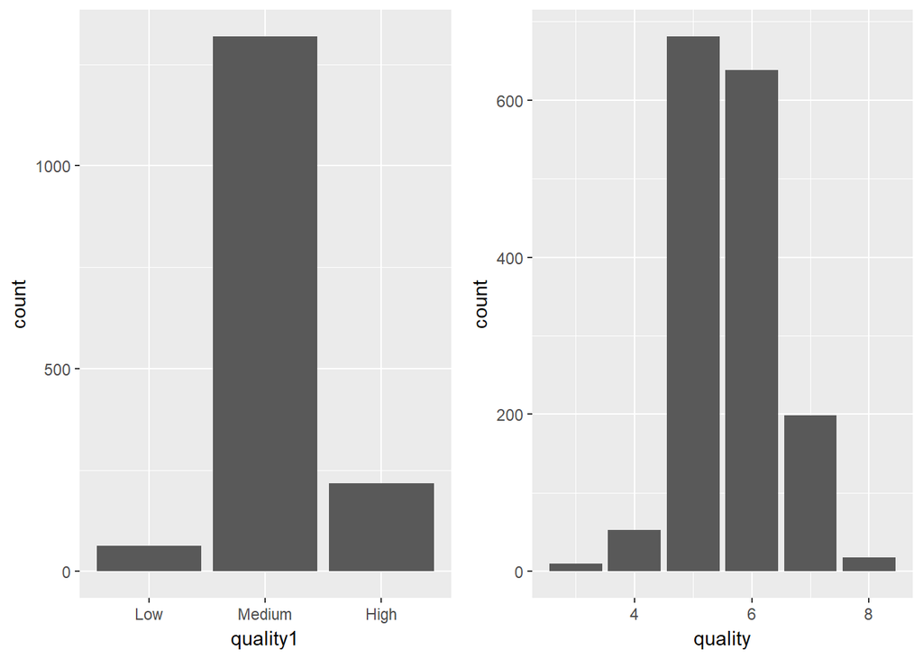

After plotting the Red Wine Dataset most wines have a quality of 5 or 6 while low quality and high quality are less common. When I created a new variable that groups quality into 3 categories, ‘Medium’ quality had the most observations.

Next I wanted to look at the characteristics (input variables) of the red wine.

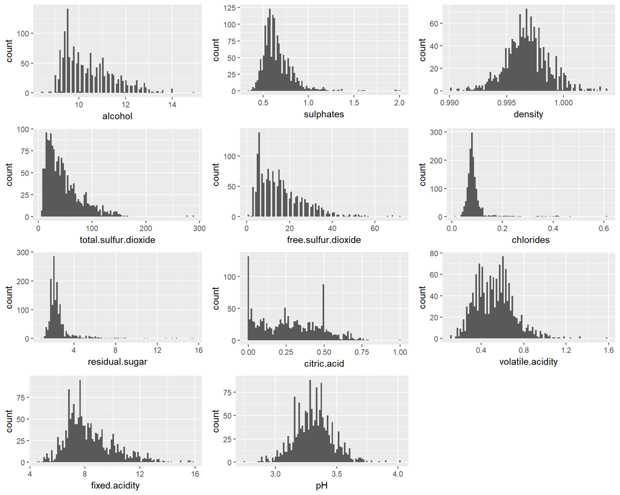

```
##    Min. 1st Qu.  Median    Mean 3rd Qu.    Max.
##   0.900   1.900   2.200   2.539   2.600  15.500
```

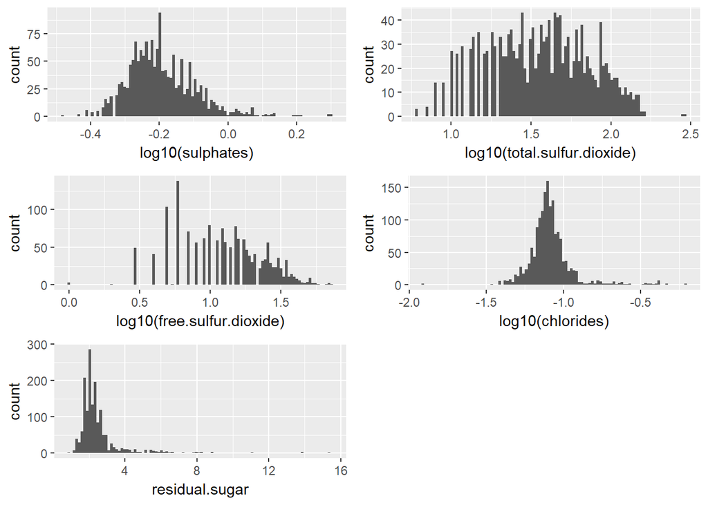

Some of the features had outliers and were not close to a normal distribution. I took the log10 of those features to get a more normal distribution.

# Univariate Analysis

### What is the structure of your dataset?

There are 1599 wine observations in the dataset. The dataset included 12 features (fixed acidity, volatile acidity, citric acid, residual sugar, chlorides, free sulfur dioxide, total sulfur dioxide, density, pH, sulphates, alcohol, quality).  
All of the features are numbered (except quality which is an integer). None of them are order factored variables.

### What is/are the main feature(s) of interest in your dataset?

The main feature of interest to me is the quality of the wine. I would like to see which other features effect the quality of the wine.

### What other features in the dataset do you think will help support your investigation into your feature(s) of interest?

Based on my current knowledge of wines. I am not sure which variables will have any correlation with the quality. However, based on the plots I would think that density and/or the citric acid would affect the quality.

### Did you create any new variables from existing variables in the dataset?

I created a new variable for wine quality. I grouped the observations in “Low”, “Medium” and “High” quality.

### Of the features you investigated, were there any unusual distributions? Did you perform any operations on the data to tidy, adjust, or change the form of the data? If so, why did you do this?

After increasing the bin size for citirc acid I noticed that quite a few wines have either 0 g/dm^3 or .49 g/dm^3 of citric acid.

# Bivariate Plots Section

```
##                      fixed.acidity volatile.acidity citric.acid
## fixed.acidity           1.00000000     -0.256130895  0.67170343
## volatile.acidity       -0.25613089      1.000000000 -0.55249568
## citric.acid             0.67170343     -0.552495685  1.00000000
## residual.sugar          0.11477672      0.001917882  0.14357716
## chlorides               0.09370519      0.061297772  0.20382291
## free.sulfur.dioxide    -0.15379419     -0.010503827 -0.06097813
## total.sulfur.dioxide   -0.11318144      0.076470005  0.03553302
## density                 0.66804729      0.022026232  0.36494718
## pH                     -0.68297819      0.234937294 -0.54190414
## sulphates               0.18300566     -0.260986685  0.31277004
## alcohol                -0.06166827     -0.202288027  0.10990325
## quality                 0.12405165     -0.390557780  0.22637251
##                      residual.sugar    chlorides free.sulfur.dioxide
## fixed.acidity           0.114776724  0.093705186        -0.153794193
## volatile.acidity        0.001917882  0.061297772        -0.010503827
## citric.acid             0.143577162  0.203822914        -0.060978129
## residual.sugar          1.000000000  0.055609535         0.187048995
## chlorides               0.055609535  1.000000000         0.005562147
## free.sulfur.dioxide     0.187048995  0.005562147         1.000000000
## total.sulfur.dioxide    0.203027882  0.047400468         0.667666450
## density                 0.355283371  0.200632327        -0.021945831
## pH                     -0.085652422 -0.265026131         0.070377499
## sulphates               0.005527121  0.371260481         0.051657572
## alcohol                 0.042075437 -0.221140545        -0.069408354
## quality                 0.013731637 -0.128906560        -0.050656057
##                      total.sulfur.dioxide     density          pH
## fixed.acidity                 -0.11318144  0.66804729 -0.68297819
## volatile.acidity               0.07647000  0.02202623  0.23493729
## citric.acid                    0.03553302  0.36494718 -0.54190414
## residual.sugar                 0.20302788  0.35528337 -0.08565242
## chlorides                      0.04740047  0.20063233 -0.26502613
## free.sulfur.dioxide            0.66766645 -0.02194583  0.07037750
## total.sulfur.dioxide           1.00000000  0.07126948 -0.06649456
## density                        0.07126948  1.00000000 -0.34169933
## pH                            -0.06649456 -0.34169933  1.00000000
## sulphates                      0.04294684  0.14850641 -0.19664760
## alcohol                       -0.20565394 -0.49617977  0.20563251
## quality                       -0.18510029 -0.17491923 -0.05773139
##                         sulphates     alcohol     quality
## fixed.acidity         0.183005664 -0.06166827  0.12405165
## volatile.acidity     -0.260986685 -0.20228803 -0.39055778
## citric.acid           0.312770044  0.10990325  0.22637251
## residual.sugar        0.005527121  0.04207544  0.01373164
## chlorides             0.371260481 -0.22114054 -0.12890656
## free.sulfur.dioxide   0.051657572 -0.06940835 -0.05065606
## total.sulfur.dioxide  0.042946836 -0.20565394 -0.18510029
## density               0.148506412 -0.49617977 -0.17491923
## pH                   -0.196647602  0.20563251 -0.05773139
## sulphates             1.000000000  0.09359475  0.25139708
## alcohol               0.093594750  1.00000000  0.47616632
## quality               0.251397079  0.47616632  1.00000000
```

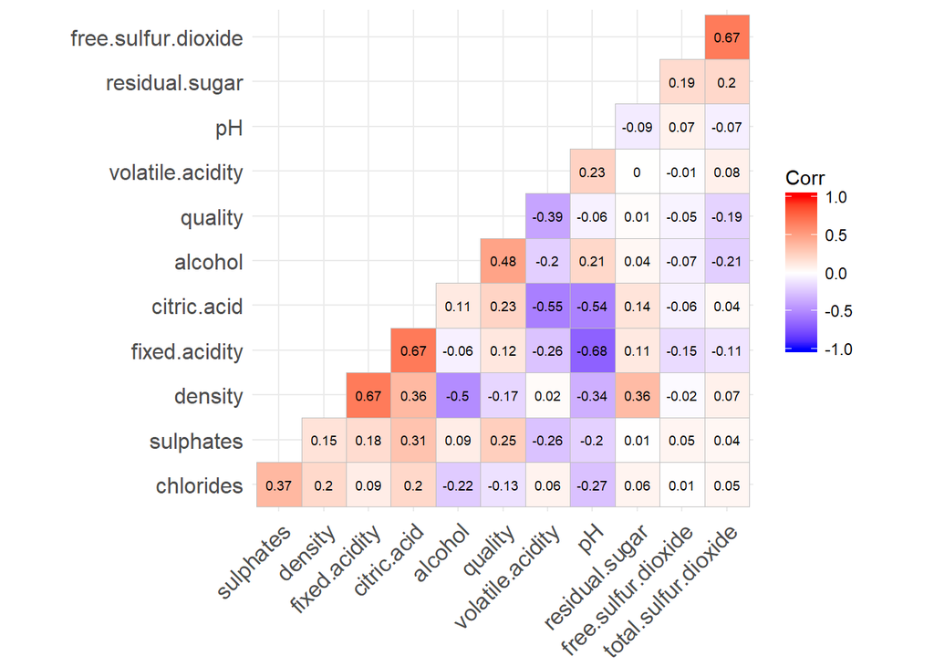

This correlation matrix indicates that there is a positive correlation between quality and alcohol, citric acid, sulphates and fixed acidity. It also shows a negative correlation between volatile acidity, total sulfur dioxide, chlorides and density.

-Quality of wine increasing

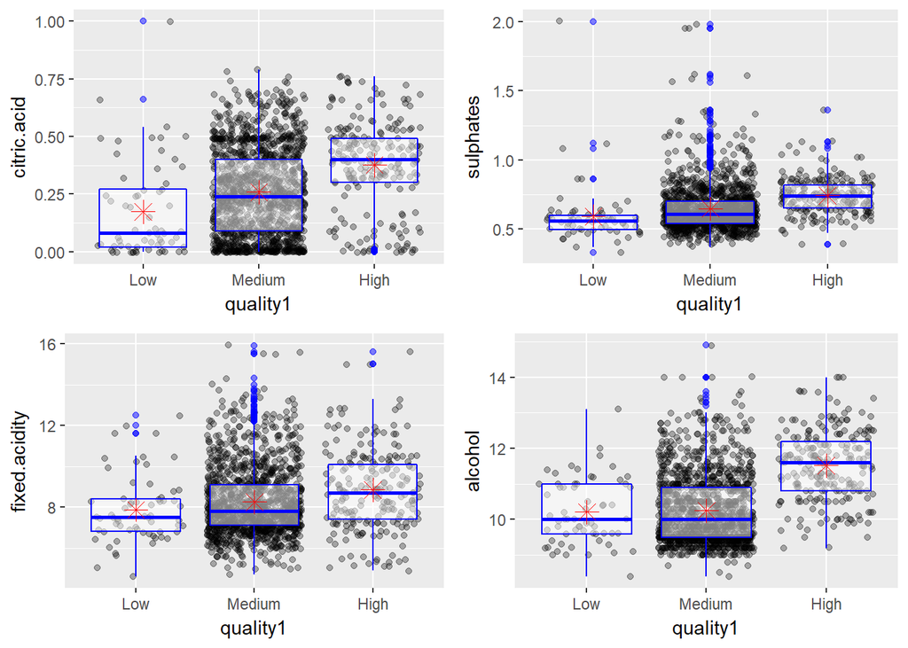

I chose to analyze Alcohol, Citric Acid, Sulphates and Fixed Acidity because they were the top positively correlated features with quality. Alcohol had the biggest correlation with quality (0.48). It looks as though alcohol content is greater in ‘High’ quality wines. All of these features seem to increase along with the quality.

-Quality of Wine decreasing

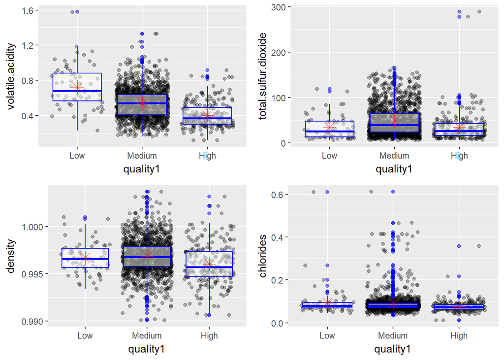

Volatile Acidity, Total Sulfur Dioxide, Density and Chlorides were the features with the largest negative correlations with the wines quality. Volatile Acidity had the biggest negative correlation with quality (-0.39). Volatile Acidity was much higher in ‘Low’ quality wines. As you can tell from the graphs the negative correlation for the other 3 features was small.

-Other Correlations

Positive Correlations

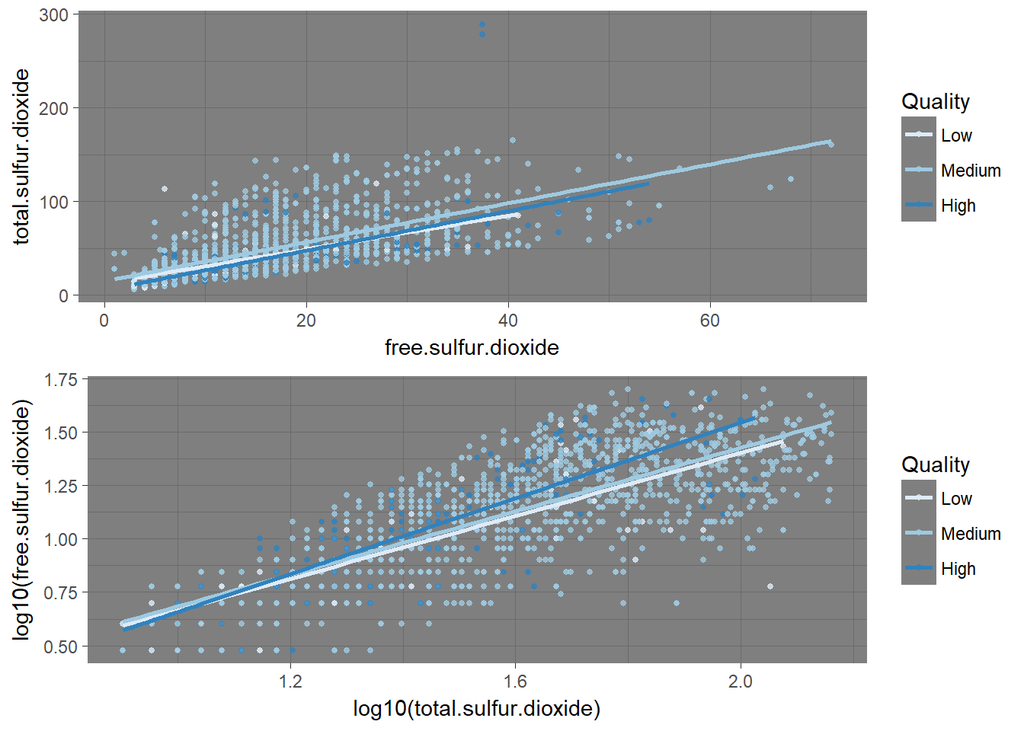

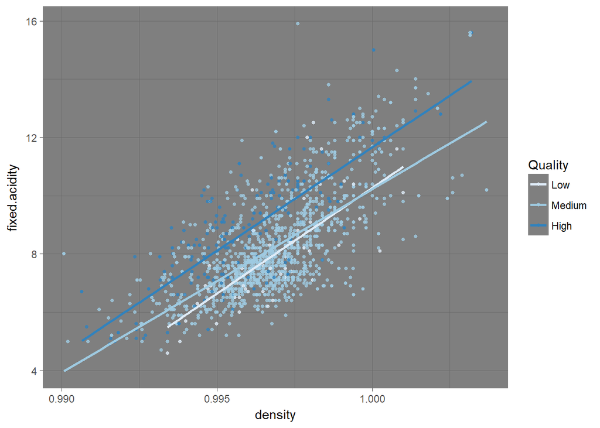

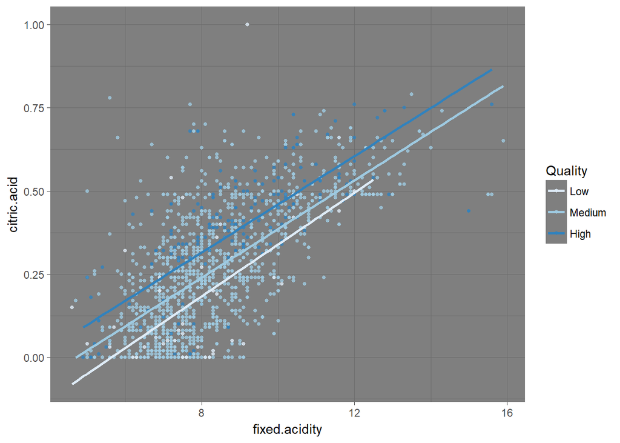

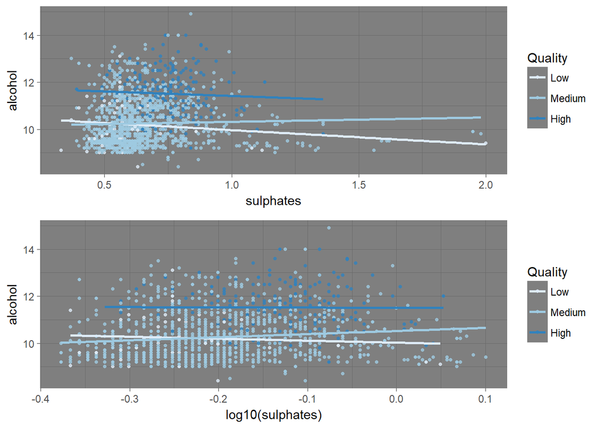

I chose to graph 3 features the greatest positive correlations. I also wanted to graph the correlation between Alcohol and Sulfates. These two features were not strongly correlated with each other. However, they were the top 2 features that were positivly correlated with the quality of the wine. As you can see, most observations have less than 1 g/dm3 of sulphates. I also wanted to log transform the graphs that were not normal distribution. I log transfored the features Free Sulfur Dioxide and Total Sulfur Dioxide.

Negative Correlations

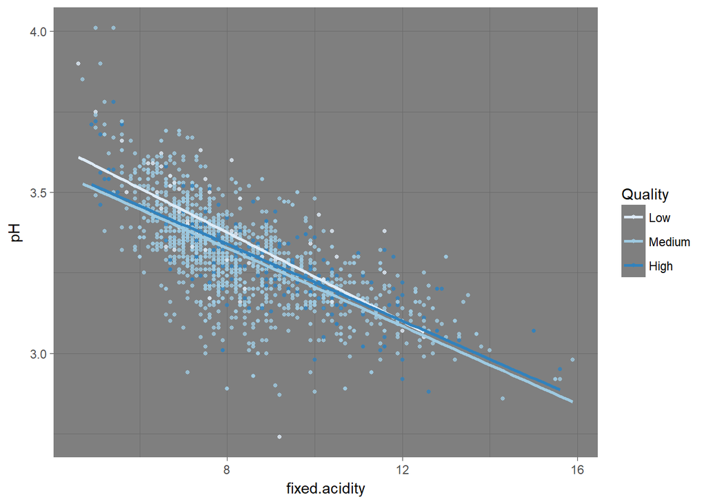

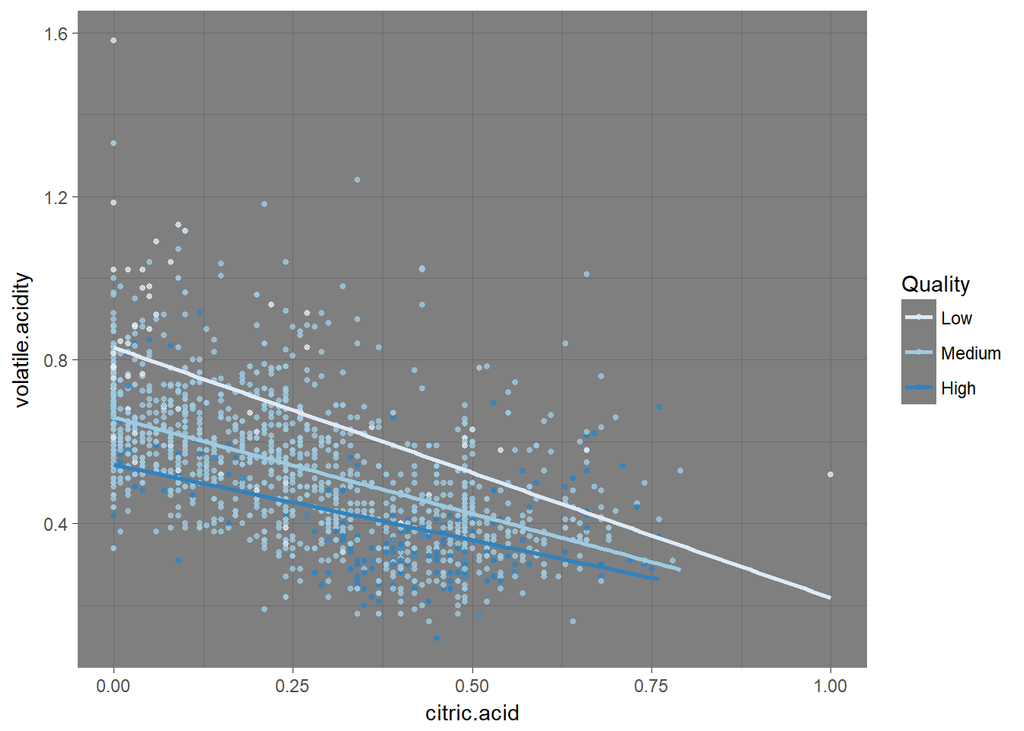

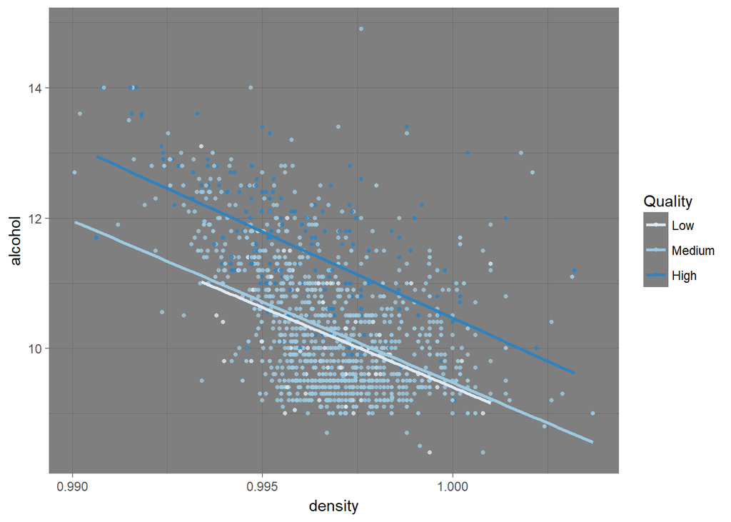

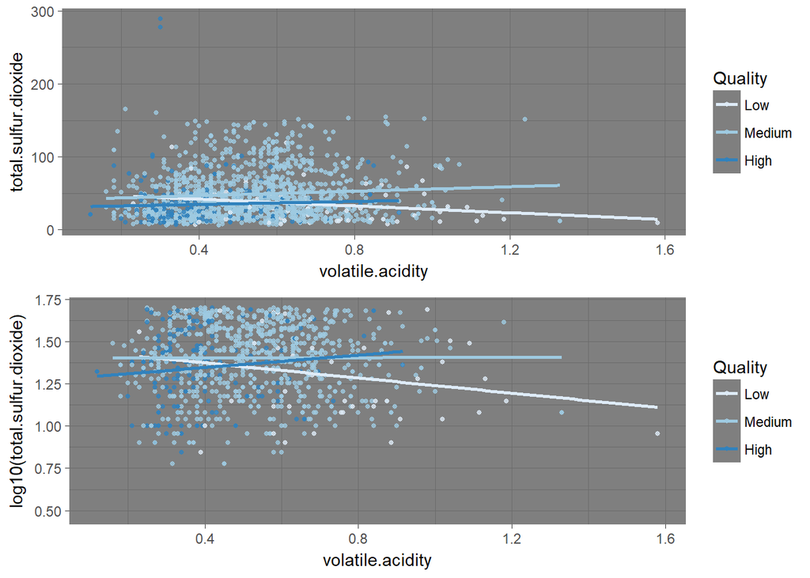

These are graphs of the 3 features with the greatest negative correlations. I also wanted to graph the correlation between Total Sulfur Dioxide and Volatile Acidity. These two features were not strongly correlated with each other. In fact they had a positive correlation with each other. However, they were the top 2 features that were negatively correlated with the quality of the wine. I log transformed Total Sulfur Dioxide to account for outliers.

# Bivariate Analysis

### Talk about some of the relationships you observed in this part of the investigation. How did the feature(s) of interest vary with other features in the dataset?

I noticed a few positive and negative correlations within the dataset.  
My main feature of interest was the observed quality of the wine. The quality of wine generally went up when there was more citric acid present. The opposite effect happend when there was more volatile acidity. The more volatile acidity, the lower quality the wine. This makes sense as both were negativly correlated.

### Did you observe any interesting relationships between the other features (not the main feature(s) of interest)?

I noticed that there were a few features in the dataset that were either negatively or positively correlated. Most of them were what I would have expected. I also looked at the relationship between alcohol and sulphates. Although they do not have a high positive correlation with eachother, they are both positively correlated with qulaity.

### What was the strongest relationship you found?

The strongest relationship that I found was the negative correlation between fixed acidity and pH.

# Multivariate Plots Section

I chose to look at some graphs of features that were positively and negatively correlated

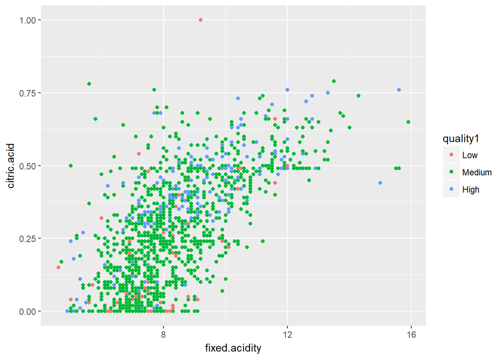

Citric Acid and Fixed Acidity were positively correlated (0.67). It looks as if the higher quality observations are positioned towards the top while a majority of lower quality observations are towards the bottom. There are low quality observations that are scattered thoughout as well.

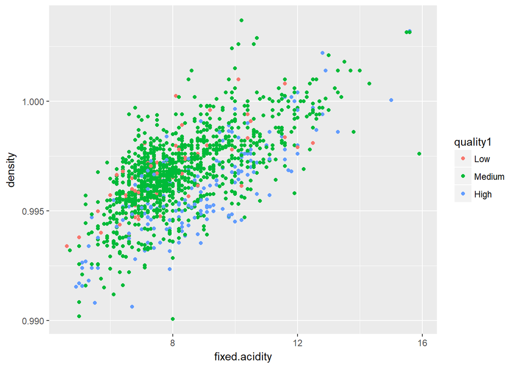

Density and Fixed Acidity are also positively correlated (0.67). It looks like a majority of the high quality observations are located to the lower right side. The medium and lower quality observations tend to fall towards the upper left side.

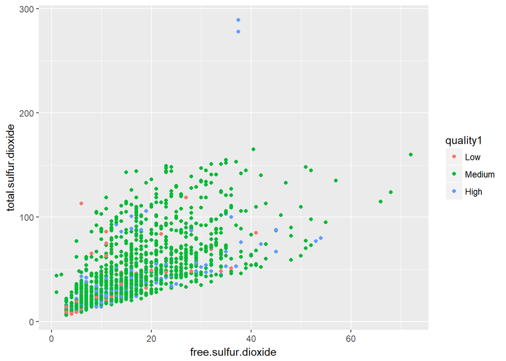

Total Sulfur Dioxide and Free Sulfur Dioxide are positively correlated as well (0.67). High quality observations look to fall on the right side while the lower and medium quality seem to lean to the left side.

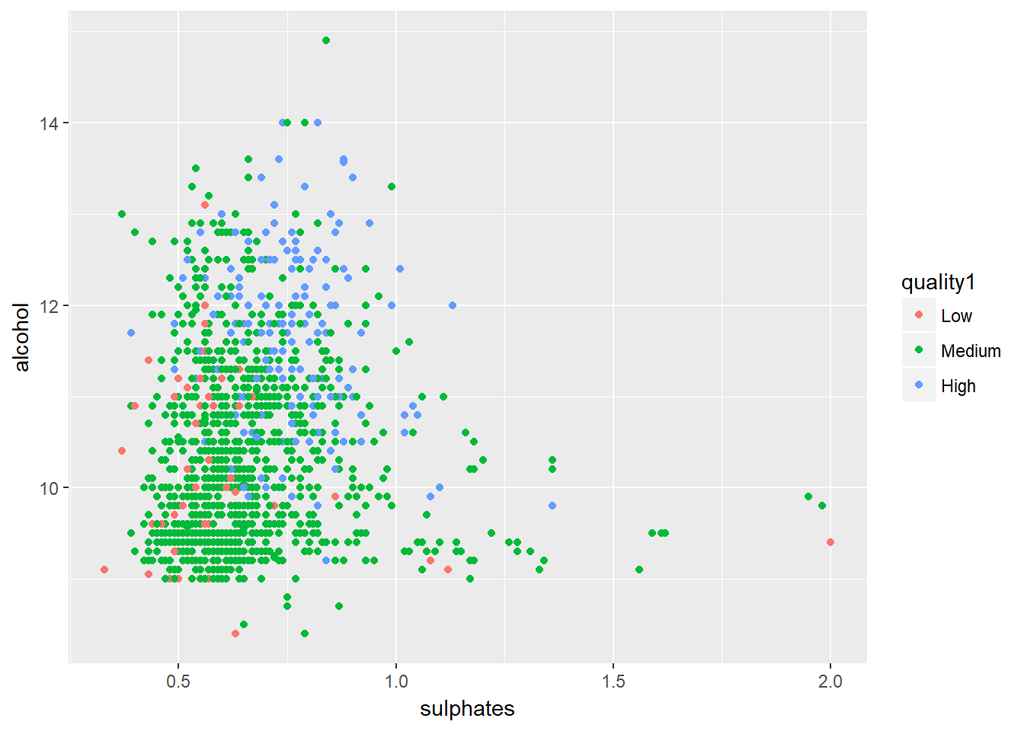

Alcohol and Sulphates were the most positively correlated features with quality. They have a weak positive correlation with each other though. The graph indicates that most high quality observations have a higher alcohol content but not necessarily more sulphates.

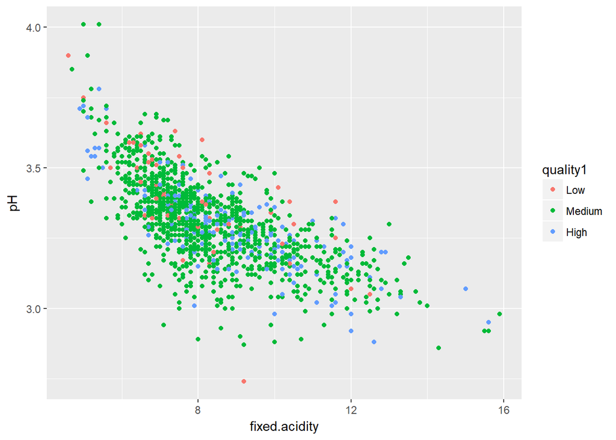

pH and Fixed Acidity are negatively correlated (-0.68). This is actually the biggest correlation between any features. It looks like the lower quality observations seem to be towards the top. You can see the one outlier near the bottom however.

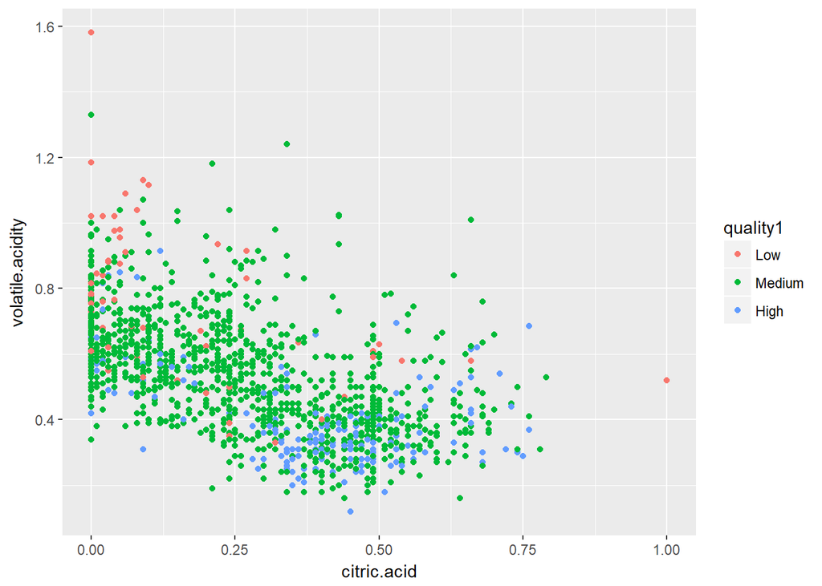

Volatile Acidity and Citric Acid were also negatively correlated (-.55). Higher quality observations are towards the bottom right while lower quality are at the top left.

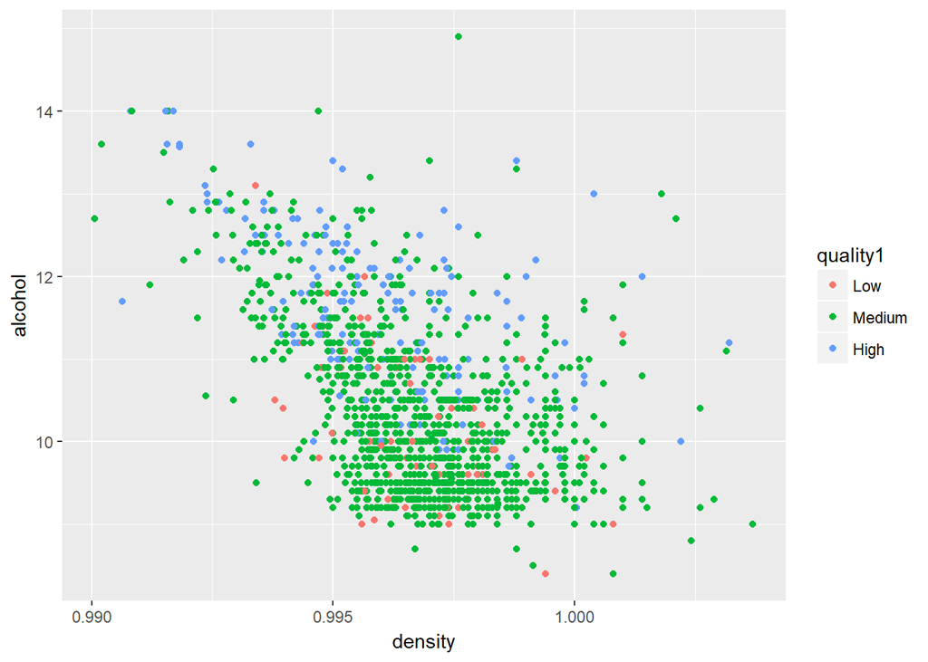

# Multivariate Analysis

### Talk about some of the relationships you observed in this part of the investigation. Were there features that strengthened each other in terms of looking at your feature(s) of interest?

### Were there any interesting or surprising interactions between features?

Because of the positive correlations between fixed acidity/citric acid, fixed acidity/density and free sulfur dioxide/total sulfur dioxide I decided to make multivariate plots showing the impact on quality. Although the graphs are a little messy, you can see that qualities are grouped together. When looking at citric acid/fixed acidity’s effects on quality you can see that high quality observations are grouped towards the top while medium is below it. The majoriy of low quality appear at the bottom as well.

# Final Plots and Summary

### Plot One

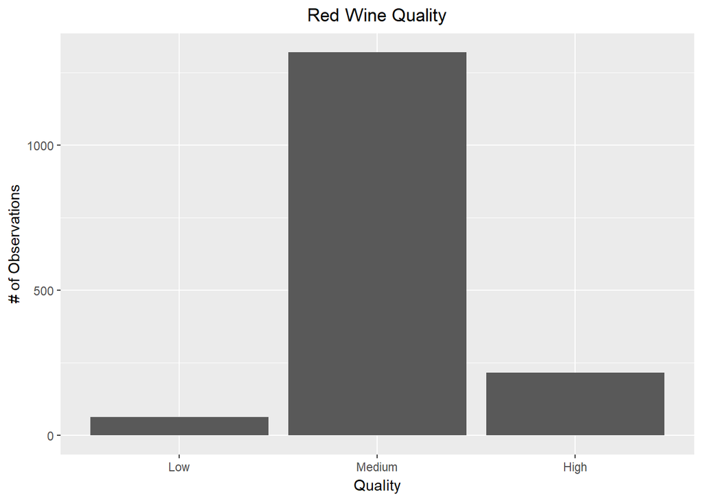

### Description One

There is a large number of observations that can be grouped into ‘Medium’ quality wine. It is more rare to find wines that are ‘Low’ quality or ‘High’ quality.

### Plot Two

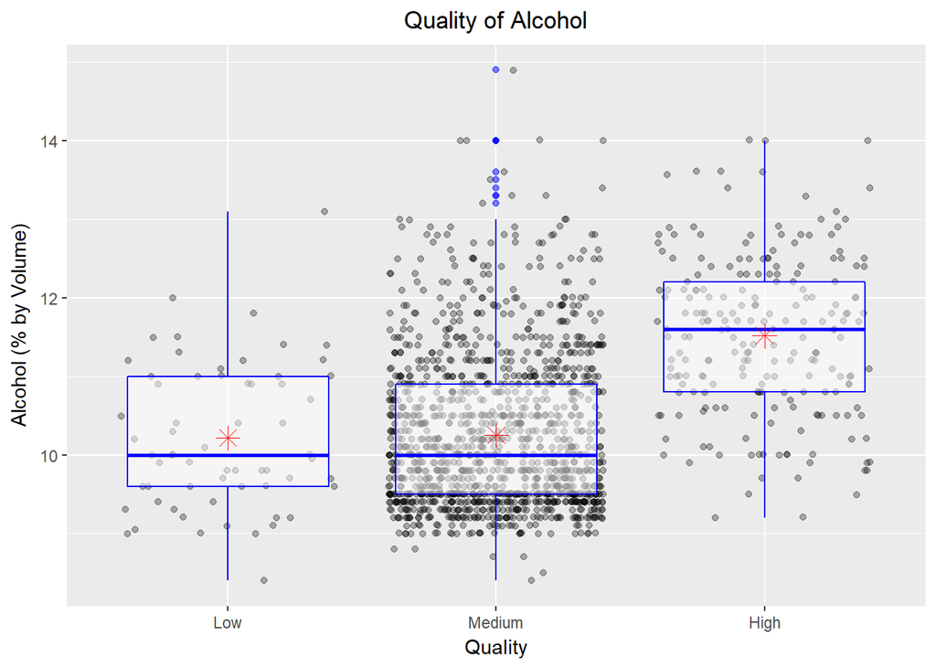

### Description Two

Alcohol had a positive correlation with quality. Higher alcohol content seemed to have more observations that were grouped into ‘High’ quality wine. This graph is significant because it is the best indicator of the quality of wine.

### Plot Three

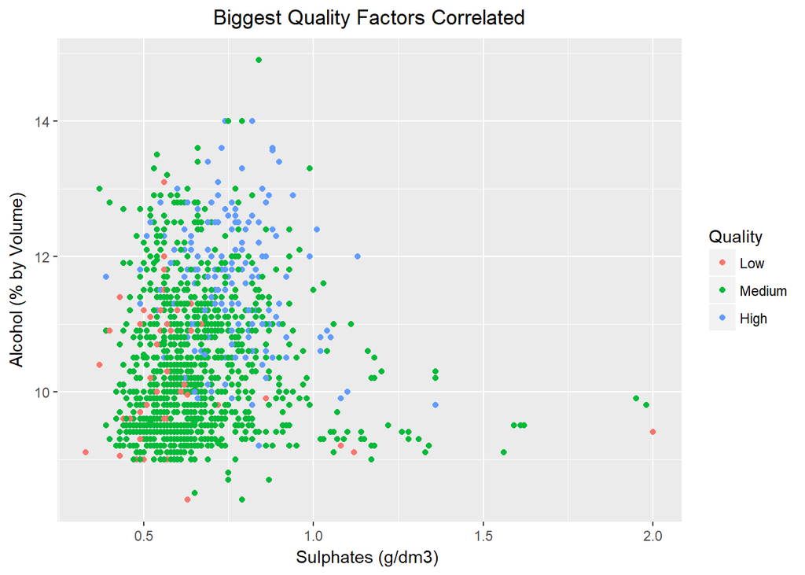

### Description Three

When you look at alcohol/sulphates relationship with quality, you can see that the points are grouped together. With the exception of outliers most of the low quality observations were on the left side of the graph. The higher quality observations seem to be higher and to the right.

# Reflection

The Red Wine dataset that I explored contained 1599 observations of quality.  
Looking into the dataset I found that interesting features such as Alcohol and Sulphates had an effect on the precieved quality of the red wine. I was able to find a correlation between quality and Alcohol and Sulphates. I was surprised to find that Alcohol had a strong correlation with quality. I would have thought the opposite. One of the problems that I found with this dataset set that quality was more of a matter of opinion. As shown by some of the outliers, I think that a persons preference has an infulence on the quality when it came to certain features. For example, someone who likes sweeter wines is going to give a higher quality rating to wines with less citric acid. In the future I would try to come up with a more solid definition of quality. Maybe find quality ratings on a sub-category of red wine. Red wine seems to be a very broad category of wine.